# AEA Report

Stuti Goyal

```r
library(tidyverse)
library(janitor)
```

```r
library(dataverse)
library(ggplot2)
library(qdapRegex)
aea_data <- get_dataframe_by_id(file = 6690545,
                             server = "dataverse.harvard.edu",.f = read.csv, original = T, )

## Yearwise Visualisations

## This can also be used to pull the dataset, but harvard dataverse's API works more
#frequently with fewer bugs with file ids
#aea_data <- get_dataframe_by_name(filename ="trials.tab", dataset = https://doi.org/10.7910/DVN/TGMJFD
#                           server = "dataverse.harvard.edu",.f = read.csv, original = T)
## Printing the metadata here
metadata <- get_dataset("https://doi.org/10.7910/DVN/TGMJFD")
### The title for the data retrieved above:
print(metadata$metadataBlocks$citation$fields$value[[1]][1])
```

```
## [1] "Registrations in the AEA RCT Registry (2013-05-15 through 2022-11-01)"
```

```r
aea_orig <- aea_data
aea_data <- clean_names(aea_data)
```

## Data Wrangling

```r
aea_data_year <- aea_data %>%
  mutate(first_registered_on = as.Date(first_registered_on, format = "%Y-%m-%d")) %>%
#   mutate(first_registered_on = str_replace(first_registered_on, "00", "20" )) %>%
  mutate(first_registered_year = format(as.Date(first_registered_on), "%Y"))
```

```r
year_cnt <- aea_data_year %>%
  group_by(first_registered_year) %>%
  summarise(cnt = n()) %>%
  ungroup()
```

```r
# Creating data set with month and year
aea_year_month <- aea_data_year %>%
  mutate(
    first_month_year = format(as.Date(first_registered_on), "%Y-%m"),
    first_month = format(as.Date(first_registered_on), "%m")
  )
```

```r
# Creating variable to reflect month (used for cumulative count predictions)
aea_year_month <- aea_data_year %>%
  mutate(
    first_month_year = format(as.Date(first_registered_on), "%m-%Y"),
    first_month = format(as.Date(first_registered_on), "%m")
  )
```

```r
# Creating counts of registrations by year
year_cnt <- aea_year_month %>%
  group_by(first_registered_year) %>%
  summarise(cnt_yr = n()) %>%
  ungroup()

#Data set of counts by year (excluding 2022)
year_wo_2022 <- year_cnt %>%
  filter(first_registered_year != 2022)
```

### Summary of code

In this section, the data has been loaded through the API, following which, the first regesitered year and month were extracted from the variable `first_registered_on`; hese variables are called `first_registered_year` and `first_month`, respectively. After this, I created a dataset which summarizes the total number of registrations for each year. I also created a dataset with these counts, but without the observations for 2022 to facilitate the predictions below.

## Predictions for total counts

```r
cnt_lm <- lm(cnt_yr ~ as.numeric(first_registered_year), data = year_wo_2022)
summary(cnt_lm)
```

```
##
## Call:
## lm(formula = cnt_yr ~ as.numeric(first_registered_year), data = year_wo_2022)
##
## Residuals:
##    Min     1Q Median     3Q    Max
## -83.22 -29.96  17.51  39.71  48.98
##
## Coefficients:
##                                     Estimate Std. Error t value Pr(>|t|)
## (Intercept)                       -2.853e+05  1.422e+04  -20.07 1.91e-07 ***
## as.numeric(first_registered_year)  1.417e+02  7.048e+00   20.11 1.88e-07 ***
## ---
## Signif. codes:  0 '***' 0.001 '**' 0.01 '*' 0.05 '.' 0.1 ' ' 1
##
## Residual standard error: 54.59 on 7 degrees of freedom
## Multiple R-squared:  0.983,  Adjusted R-squared:  0.9806
## F-statistic: 404.4 on 1 and 7 DF,  p-value: 1.882e-07
```

```r
# Creating data frame with prediction for 2022
years <- data.frame(first_registered_year = c(2022))

pred_cnt_2022 <- data.frame(year = c(2021, 2022), cnt = c(year_cnt$cnt_yr[year_cnt$first_registered_year == "2021"], predict(cnt_lm, years)))
```

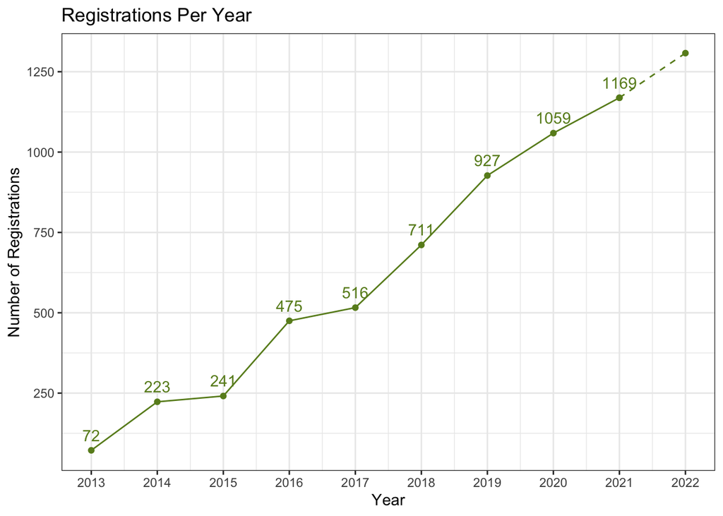

```r
year_wo_2022 %>%
  mutate(first_registered_year = as.numeric(first_registered_year)) %>%
  ggplot(aes(x = first_registered_year, y = cnt_yr)) +
  geom_line(color = "olivedrab4") +
  geom_text(aes(label = cnt_yr), color = "olivedrab4", position = position_nudge(y = -2), vjust = -0.9) +
  geom_line(aes(x = year, y = cnt), data = pred_cnt_2022, linetype = "dashed", color = "olivedrab4") +
  geom_point(aes(x = year, y = cnt), data = pred_cnt_2022, color = "olivedrab4") +
  geom_point(color = "olivedrab4") +
  scale_x_continuous(
    name = "Year",
    breaks = 2013:2022
  ) +
  scale_y_continuous(
    breaks = seq(0, 1500, 250)
  ) +
  # geom_text(aes(y = round(pred_cnt_2022$cnt[pred_cnt_2022$year == "2022"], 2), x = 2022, label = round(pred_cnt_2022$cnt[pred_cnt_2022$year == "2022"], 2)), color = "olivedrab4") +
  labs(title = "Registrations Per Year", y = "Number of Registrations") +
  theme_bw()
```

### Summary of code

In this section, I created a linear regression model to predict the total number of registrations in 2022, based on the year. For this, I used the dataset with the registration counts for each year (excluding 2022). I did this since the data reflected records until October of 2022, which means that using the existing data would be an inaccurate reflection of the number of registratiuons in 2022. Finally, I graphed the existing data and the predictions, with the prediction indicated by a dashed line.

```r
ggsave("reg_pre_year.pdf")
```

## Predictions for cumulative counts

```r
cnt_mnth_yr_2022 <- aea_year_month %>%
  filter(first_registered_year == "2022") %>%
  group_by(first_month) %>%
  summarise(cnt = n()) %>%
  ungroup()
```

```r
yr_cnt_no_2022 <- filter(year_cnt, first_registered_year != "2022")

cum_cnt_no_2022 <- data.frame(
  cum_cnt = cumsum(yr_cnt_no_2022[, 2])
  )

cum_cnt_no_2022 <- cbind(yr_cnt_no_2022[, 1], cum_cnt_no_2022)
```

```r
years <- data.frame(first_registered_year = c(2022))

cnt_2022 <- data.frame(
  "year" = c(2021, 2022),
  "cnt" = c(
    cum_cnt_no_2022$cnt_yr[cum_cnt_no_2022$first_registered_year == "2021"],
    ( predict(cnt_lm, years)+ cum_cnt_no_2022$cnt_yr[cum_cnt_no_2022$first_registered_year == "2021"])
  )
)
```

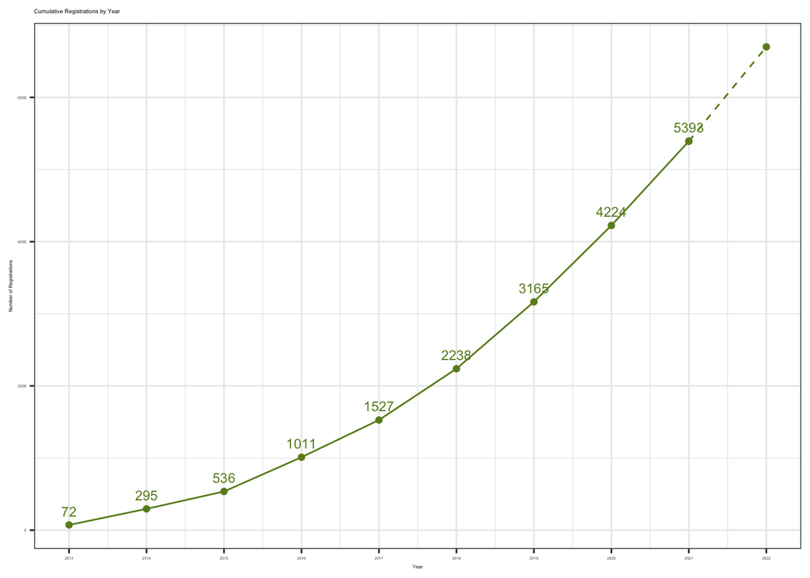

```r
cum_cnt_no_2022 %>%
  mutate(first_registered_year = as.numeric(first_registered_year)) %>%
  ggplot(mapping = aes(x = first_registered_year, y = cnt_yr)) +
  geom_line(color = "olivedrab4") +
  geom_point(color = "olivedrab4") +
  geom_line(
    data = cnt_2022,
    mapping = aes(x = year, y = cnt),
    linetype = "dashed",
    color = "olivedrab4"
  ) +
  geom_point(
    data = cnt_2022,
    mapping = aes(x = year, y = cnt),
    color = "olivedrab4"
  ) +
  geom_text(
    aes(x = first_registered_year, y = cnt_yr, label = cnt_yr),
    vjust = -0.9,
    color = "olivedrab4",
    size = 3
  ) +
  scale_x_continuous(
    breaks = 2013:2022
  ) +
  labs(
    title = "Cumulative Registrations by Year",
    x = "Year",
    y = "Number of Registrations"
  ) +

  theme_bw() +
  theme(
    text = element_text(size = 3)
  )
```

```r
ggsave("reg_cumulative.pdf", width = 3, height = 3)
```

## Predictions for pre vs post reg

```r
aea_data_year <- aea_data_year %>%
  mutate(intervention_start_date = as.Date(intervention_start_date, format = "%Y-%m-%d"))
# %>%
#   mutate(intervention_start_date = str_replace(intervention_start_date, "00", "20" ))
```

```r
pre_reg_cnt <- aea_data_year %>%
  mutate(pre_post = ifelse(first_registered_on < intervention_start_date, "pre_reg", "post_reg")) %>%
  group_by(first_registered_year, pre_post) %>%
  summarise(reg_cnt = n()) %>%
  ungroup()
pre_reg_no_2022 <- pre_reg_cnt %>%
  filter(first_registered_year != "2022")
```

```r
pre_reg_lm <- lm(reg_cnt ~ as.numeric(first_registered_year) + pre_post, data = pre_reg_no_2022)
summary(pre_reg_lm)
```

```
##
## Call:
## lm(formula = reg_cnt ~ as.numeric(first_registered_year) + pre_post,
##     data = pre_reg_no_2022)
##
## Residuals:
##     Min      1Q  Median      3Q     Max
## -124.02  -37.60   12.69   35.18  126.87
##
## Coefficients:
##                                     Estimate Std. Error t value Pr(>|t|)
## (Intercept)                       -1.426e+05  1.248e+04 -11.429 8.39e-09 ***
## as.numeric(first_registered_year)  7.087e+01  6.186e+00  11.457 8.12e-09 ***
## pre_postpre_reg                   -9.589e+01  3.194e+01  -3.002  0.00894 **
## ---
## Signif. codes:  0 '***' 0.001 '**' 0.01 '*' 0.05 '.' 0.1 ' ' 1
##
## Residual standard error: 67.76 on 15 degrees of freedom
## Multiple R-squared:  0.9034, Adjusted R-squared:  0.8905
## F-statistic: 70.13 on 2 and 15 DF,  p-value: 2.441e-08
```

```r
years_reg <- data.frame(first_registered_year = c(2022), pre_post = c("post_reg", "pre_reg"))

reg_pred_2022 <- data.frame(
  year = c("2021", "2021", "2022", "2022"),
  pre_post = c("pre_reg", "post_reg"),
  cnt = c(
    pre_reg_cnt$reg_cnt[pre_reg_cnt$first_registered_year == "2021" & pre_reg_cnt$pre_post == "pre_reg"],
    pre_reg_cnt$reg_cnt[pre_reg_cnt$first_registered_year == "2021" & pre_reg_cnt$pre_post == "post_reg"],
    predict(pre_reg_lm, years_reg))
  )
```

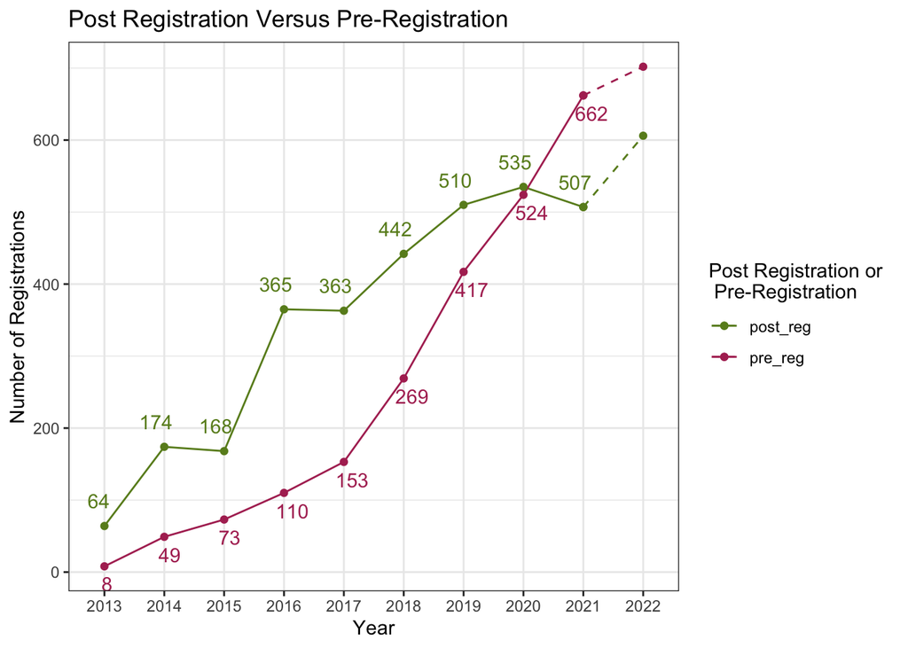

```r
ggplot(data = pre_reg_no_2022, mapping = aes(x = first_registered_year, y = reg_cnt, color = pre_post)) +
  geom_path(aes(group = pre_post)) +
  geom_point() +
  theme_bw() +
  geom_path(aes(x = year, y = cnt, color = pre_post, group = pre_post), data = reg_pred_2022, linetype = "dashed") +
  geom_point(aes(x = year, y = cnt, color = pre_post), data = reg_pred_2022) +
  geom_text(
    data = filter(pre_reg_no_2022, pre_post == "post_reg"),
    aes(x = first_registered_year, y = reg_cnt, label = reg_cnt), vjust = -1.25, hjust = 0.75,
    color = "olivedrab4"
  ) +
  geom_text(
    data = filter(pre_reg_no_2022, pre_post == "pre_reg"),
    aes(x = first_registered_year, y = reg_cnt, label = reg_cnt), vjust = 1.75, hjust = 0.25,
    color = "maroon"
  ) +
  scale_color_manual(
    values = c("olivedrab4", "maroon")
  ) +
  labs(
    title = "Post Registration Versus Pre-Registration",
    x = "Year",
    y = "Number of Registrations",
    color = "Post Registration or \n Pre-Registration"
  )
```

```r
ggsave("post_pre_reg.pdf")
```

## Predictions for pap vs total counts

```r
pap_cnt <- aea_data_year %>%
  filter(analysis_plan_documents != "None") %>%
  group_by(first_registered_year) %>%
  summarise(pap_cnt = n()) %>%
  cbind(year_cnt[, 2])

pap_wo_2022 <- pap_cnt %>%
  filter(first_registered_year != 2022)
```

```r
pap_lm <- lm(pap_cnt ~ as.numeric(first_registered_year), data = pap_wo_2022)
summary(pap_lm)
```

```
##
## Call:
## lm(formula = pap_cnt ~ as.numeric(first_registered_year), data = pap_wo_2022)
##
## Residuals:
##     Min      1Q  Median      3Q     Max
## -39.933 -17.533   5.267  13.467  37.267
##
## Coefficients:
##                                     Estimate Std. Error t value Pr(>|t|)
## (Intercept)                       -1.236e+05  6.544e+03  -18.89 2.90e-07 ***
## as.numeric(first_registered_year)  6.140e+01  3.244e+00   18.93 2.86e-07 ***
## ---
## Signif. codes:  0 '***' 0.001 '**' 0.01 '*' 0.05 '.' 0.1 ' ' 1
##
## Residual standard error: 25.13 on 7 degrees of freedom
## Multiple R-squared:  0.9808, Adjusted R-squared:  0.9781
## F-statistic: 358.2 on 1 and 7 DF,  p-value: 2.859e-07
```

```r
pap_reg <- data.frame(first_registered_year = c(2022))

pap_pred_2022 <- data.frame(
  year = c(2021, 2022),
  pap_cnt = c(
    pap_cnt$pap_cnt[pap_cnt$first_registered_year == "2021"],
    predict(pap_lm, pap_reg)),
  cnt_yr = c(
    pap_cnt$cnt_yr[pap_cnt$first_registered_year == "2021"],
    predict(cnt_lm, pap_reg))
  )
```

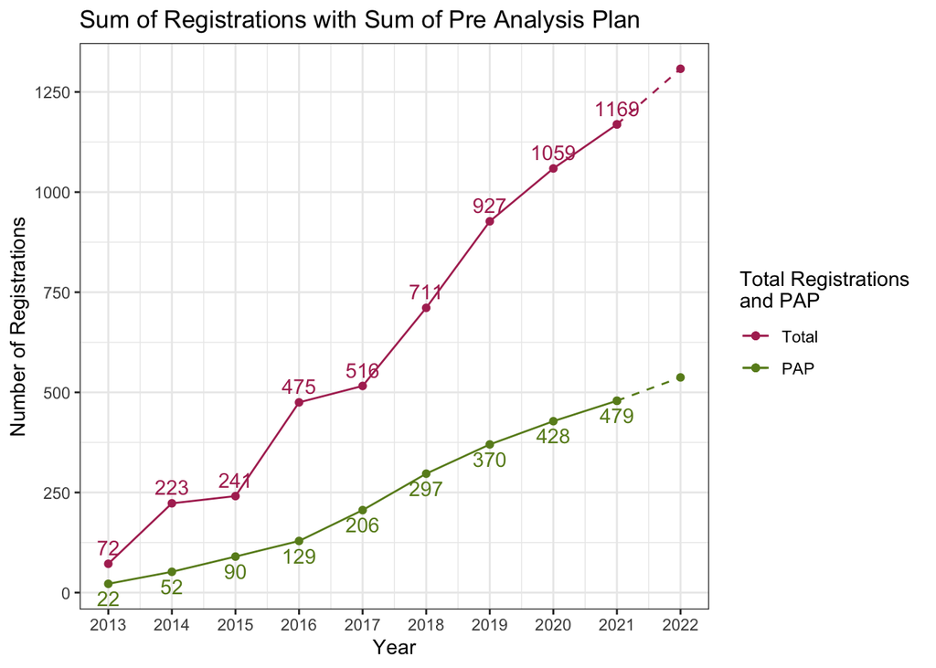

```r
pap_wo_2022 %>%
  mutate(first_registered_year = as.numeric(first_registered_year)) %>%
  ggplot() +
  geom_line(aes(x = first_registered_year, y = pap_cnt, color = "PAP")) +
  geom_point(aes(x = first_registered_year, y = pap_cnt, color = "PAP")) +
  geom_line(
    data = pap_pred_2022,
    mapping = aes(x = year, y = pap_cnt, color = "PAP"),
    linetype = "dashed"
  ) +
  geom_point(
    data = pap_pred_2022,
    mapping = aes(x = year, y = pap_cnt, color = "PAP")
  ) +
  geom_line(aes(x = first_registered_year, y = cnt_yr, color = "Total")) +
  geom_point(aes(x = first_registered_year, y = cnt_yr, color = "Total")) +
  geom_line(
    data = pap_pred_2022,
    mapping = aes(x = year, y = cnt_yr, color = "Total"),
    linetype = "dashed"
  ) +
  geom_point(
    data = pap_pred_2022,
    mapping = aes(x = year, y = cnt_yr, color = "Total")
  ) +
  scale_color_manual(
    values = c("Total" = "maroon", "PAP" = "olivedrab4")
  ) +
  theme_bw() +
  scale_x_continuous(
    breaks = 2013:2022
  ) +
  scale_y_continuous(
    breaks = seq(0, 1500, 250)
  ) +
  labs(
    title = "Sum of Registrations with Sum of Pre Analysis Plan",
    x = "Year",
    y = "Number of Registrations",
    color = "Total Registrations \nand PAP"
  ) +
  geom_text(
    aes(x = first_registered_year, y = pap_cnt, label = pap_cnt),
    vjust = 1.5,
    color = "olivedrab4"
  ) +
  geom_text(
    aes(x = first_registered_year, y = cnt_yr, label = cnt_yr),
    vjust = -0.6,
    color = "maroon"
  )
```

```r
ggsave("pap_reg.pdf")
```

## Predictions for percentage PAP

```r
pap_wo_2022 <- pap_wo_2022 %>%
  mutate(pap_percent = (pap_cnt / cnt_yr))

pap_pred_2022 <- pap_pred_2022 %>%
  mutate(pap_percent = (pap_cnt / cnt_yr))
```

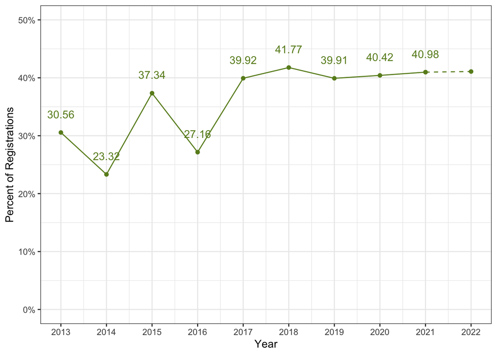

```r
pap_wo_2022 %>%
  mutate(first_registered_year = as.numeric(first_registered_year)) %>%
  ggplot() +
  geom_line(
    mapping = aes(x = first_registered_year, y = pap_percent),
    color = "olivedrab4"
  ) +
  geom_point(
    mapping = aes(x = first_registered_year, y = pap_percent),
    color = "olivedrab4"
  ) +
  geom_line(
    data = pap_pred_2022,
    mapping = aes(x = year, y = pap_percent),
    linetype = "dashed",
    color = "olivedrab4"
  ) +
  geom_point(
    data = pap_pred_2022,
    mapping = aes(x = year, y = pap_percent),
    color = "olivedrab4"
  ) +
  geom_text(
    aes(x = first_registered_year, y = pap_percent, label = round(pap_percent * 100, 2)),
    vjust = -1.85,
    color = "olivedrab4"
  ) +
  labs(
    name = "Percentage of PAP Registered",
    x = "Year",
    y = "Percent of Registrations"
  ) +
  scale_y_continuous(
    labels = scales::percent,
    limits = c(0, 0.5)
  ) +
  scale_x_continuous(
    breaks = 2013:2022
  ) +
  theme_bw()
```

```r
ggsave("pap_per_reg.pdf")
```

Functions to help split and reshape data such that one observation is one project-PI pair:

```r
#### Functions:
sep_help <- function(col, sep){
  max <- 0
  for (i in 1:length(col)){
    if (is.na(col[i])){
      next
    }
    iter <- str_count(col[i], sep)
    if (iter > max){
      max = iter
    }
    else{
      next
    }
  }
  return(max)
}

sep_ls <- function(col,sep,name){
  num <- sep_help(col,sep)
  num <- num + 1
  nums <- 1:num
  listy <-  paste(name, nums,sep = "")
  return(listy)
}
better_sep <- function(df,col,sep,name){
  names <- sep_ls(col,sep,name)
  str <-deparse(substitute(col))
  co <- sub(".*\\$", "",str)
  new_df <- df %>%
    separate(co, names, sep =sep)
  return(new_df)
}

reshape_long <- function(df, var_name){
  nms <- colnames(df)
  end1 <- str_detect(nms,var_name)
  end <- sum(end1 == TRUE)
  vn <- paste(var_name,"1",sep = "")
  pos <-match(vn, nms)
  pos_min <- pos-1
  nms <- nms[1:pos_min]
  nms <- c(nms, var_name)
  new_df <- data.frame(matrix(ncol= length(nms), nrow = 0))
  colnames(new_df) <- nms
  for (q in 1:nrow(df)){
    iter <- df[q,]
    bool <- sapply(df, is.na)[q,]
    x<-1
    e <- var_name
    for (i in x:end){
      y <- paste(e,i, sep = "")
      if (bool[y] == TRUE){
        break
      }
      else{
        x = x+1
      }
    }
    x = x-1
    df_dup <- iter[rep(seq_len(nrow(iter)), each = x), ]
    df_new <- data.frame(matrix(ncol= length(new_df), nrow = x))
    df_new[,1:pos_min] <- df_dup[,1:pos_min]
    colnames(df_new) <- nms
    j = pos
    for (k in 1:nrow(df_new)){
      res <- as.character(df_dup[k,j])
      df_new[k,pos] = res
      j = j+1
    }
    new_df <- rbind(new_df, df_new)
  }
  return(new_df)
}
```

## Graphing the growth of registered users

The following graphs the growth in the number of users registered on the AEA website (that is, those that have created a profile and are therefore capable of submitting trials). The data itself is from a previous AEA report (in 2019, available [here](https://docs.google.com/document/d/1Pc-6rsAwGzNDvTCMfh7G9ifaGyoIMJOz/edit). A transition in the web developer responsible for the website’s maintenance prevents us from having numbers for 2020 and 2021. The number in 2022 is estimated by taking the number of registered users in 2022 through December 1 (8255), and then adding the monthly average growth between 2018 and 2022 (100).

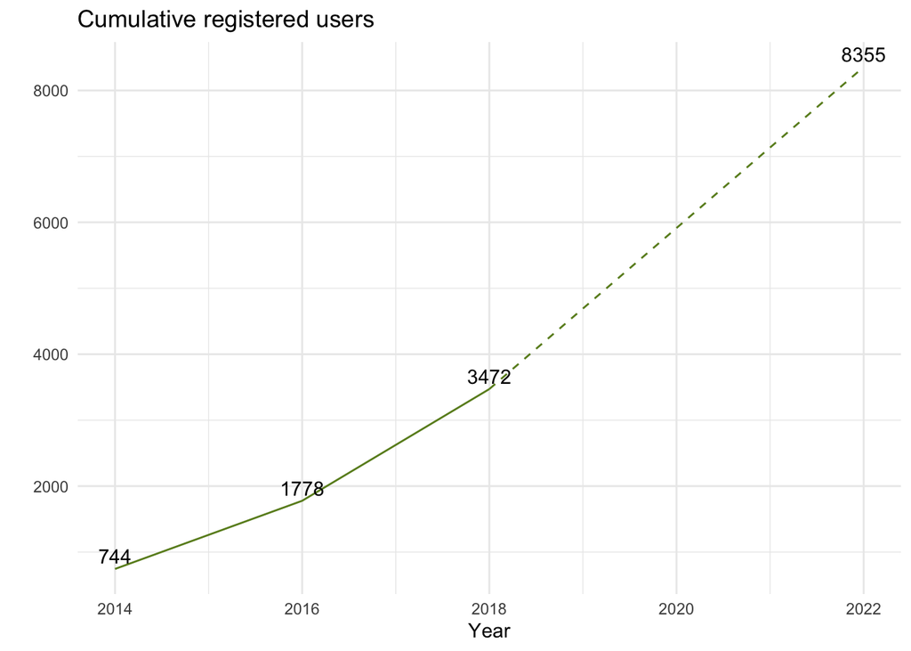

```r
years <- c(2014,2016,2018,2022)
cum_reg_users <- c(744,1778,3472,8355)
df <- data.frame(Year = years, Registered.users = cum_reg_users)

b <- ggplot(data=df, aes(x=Year,y=Registered.users))+
  geom_line(data = subset(df, Year <=2018), aes(y = Registered.users, group = 1), color = "olivedrab4", linetype = 1) +
  geom_line(data = subset(df, Year >=2018), aes(y = Registered.users, group = 1), color = "olivedrab4", linetype = 2) +
  ggtitle("Cumulative registered users") +
  geom_text(y= df$Registered.users,label= df$Registered.users, vjust = -.4) +
  labs(y= "", x= "Year") +
  theme(text = element_text(size = 20)) +
  theme_minimal()
b
```

```r
ggsave("registered_users.png", b, width = 3, height = 3)
```

## Getting the number of active users

Here active users are defined as those that either:

- Have a trial that is currently active (before its end date) on the registry
- Have a trial that they have updated within the last year on the registry

This will be a rough number, because there is heterogeneity in how PI’s names are spelled from one trial to another (and so may therefore be a slight overcount). Efforts are taken to homogenize, but there may still be some duplicate PIs in the final count.

```r
### Getting number of active users:
# Defined by # of PIs with active projects or on registrations that have been updated in the last year

## First getting the right subset
aea_sm <- select(aea_orig, c(Title, Last.update.date,End.date,Primary.Investigator,Other.Primary.Investigators))

aea_sm$Last.update.date <- as.Date(aea_sm$Last.update.date, format = "%B %d, %Y")
aea_sm$End.date <- as.Date(aea_sm$End.date)

today <- Sys.Date()

aea_sm <- filter(aea_sm, End.date >= today | Last.update.date >= "2022-01-01")


### Then we separate out the PIs:
Oth <- select(aea_sm, -c(Primary.Investigator))

Oth <- better_sep(Oth,Oth$Other.Primary.Investigators,"; ","PIs")
Oth_long <- reshape_long(Oth,"PIs")

Prim <- aea_sm %>%
  dplyr::rename(PI = Primary.Investigator) %>%
  select(PI)

Oth <- Oth_long %>%
  dplyr::rename(PI = PIs) %>%
  select(PI)

fin <- rbind(Prim,Oth)

fin$PI <- str_trim(fin$PI)
fin <- filter(fin, PI != "")

fin$PI <- gsub("\\s*\\([^\\)]+\\)","",as.character(fin$PI))

fin$PI <- rm_email(fin$PI)
fin$PI <- str_trim(fin$PI)

fin$PI <- sub("^(\\S*\\s+\\S+).*", "\\1", fin$PI)

fin$PI <- tolower(fin$PI)
fin <- distinct(fin,PI)
fin <- fin[order(fin$PI),]

printer <- paste0("The number of active registered users is: ",nrow(fin))
print(printer)
```

[output not shown]